# Aplicações

## Cálculo de área

Para calcular a área de ocorrência de uma espécie, a maioria dos trabalhos usa dados binários. Isto é, primeiro precisamos binarizar os rasters. O próximo passo é descobrir o tamanho da célula do raster (através da resolução dele). Multiplicando o raster binário pelo tamanho da célula temos um mapa com dois valores: zero e o tamanho da célula. Se somarmos todos os valores do raster teremos, então, o valor da área da espécie. Faríamos isso da seguinte forma:

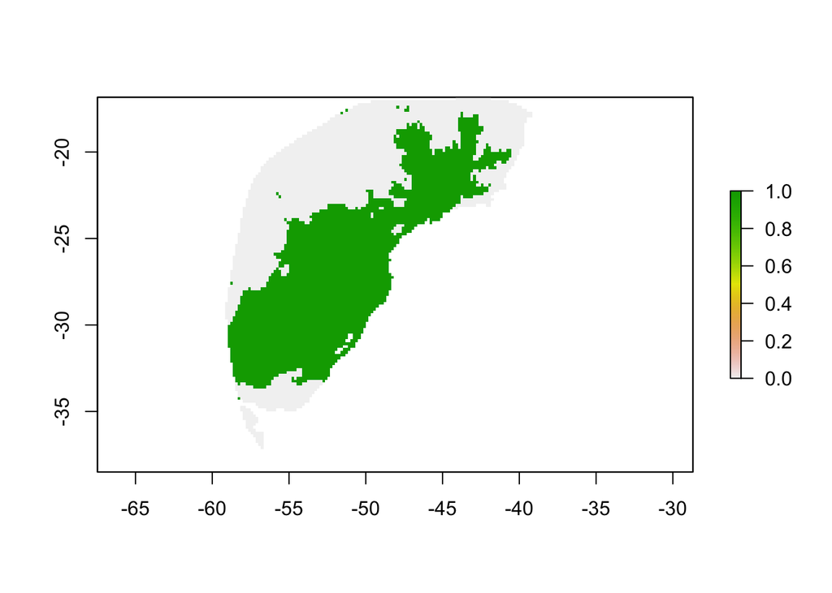

```r
e <- e1
e[] <- ifelse(e[] > 0.5, 1,0) # binarizar raster
plot(e)
```

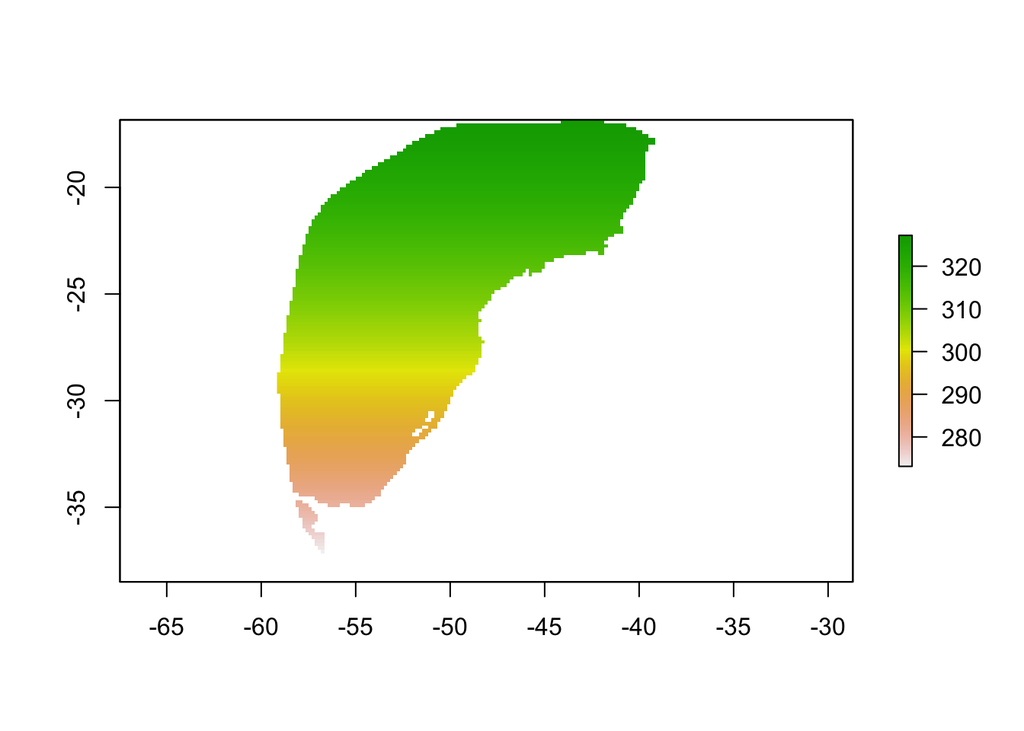

```r
cell_size <- raster::area(e, na.rm=TRUE, weights=FALSE) # obter tamanho das células
plot(cell_size)
```

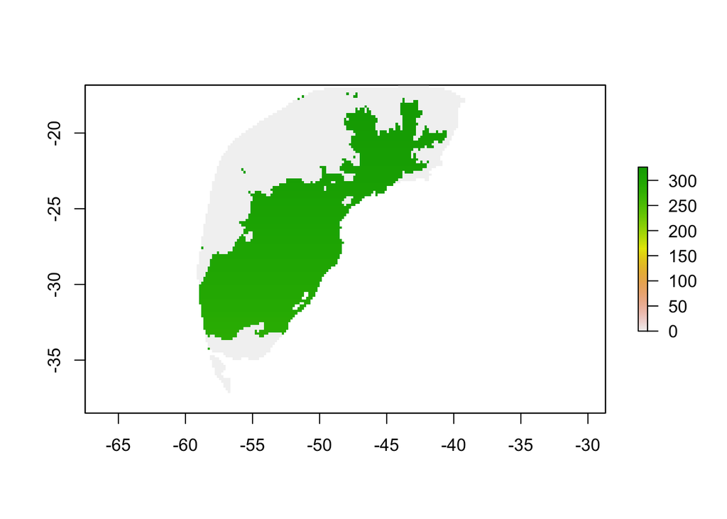

```r
e <- cell_size*e
plot(e) # perceba a mudança na escala
```

```r
resultado <- cellStats(e, sum) # cálculo em km2
resultado
```

```
## [1] 1144682
```

Uma alternativa que eu costumo usar para fugir de binarizações (pois elas geralmente levam à subjetividade) é multiplicar o tamanho das células pelo mapa de probabilidades de ocorrência. Isso pode ser feito exatamente da mesma forma que no bloco de código anterior, mas pulando a etapa de binzarização. A lógica implicita é que, se a probabilidade de ocorrência da espécie em uma célula é menor, logo a área ocupada dentro da célula também deve ser menor.

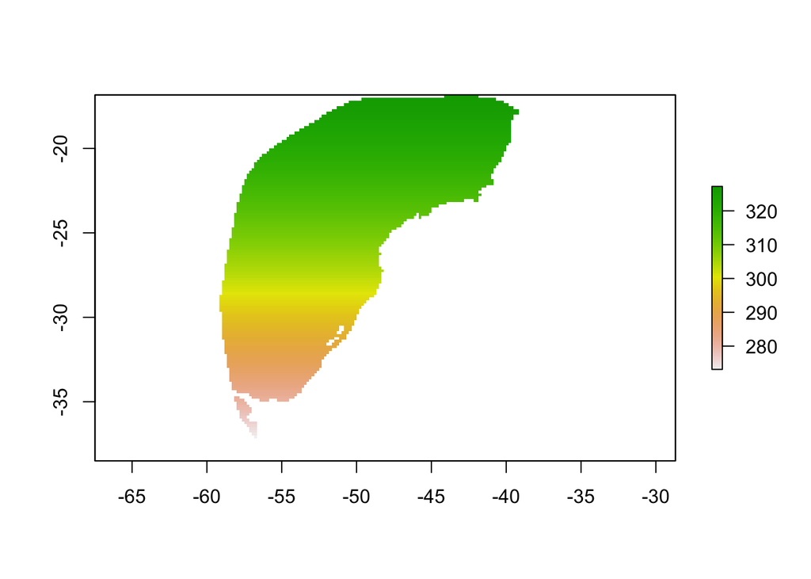

```r
e <- e1
cell_size <- raster::area(e, na.rm=TRUE, weights=FALSE) # obter tamanho das células
plot(cell_size)
```

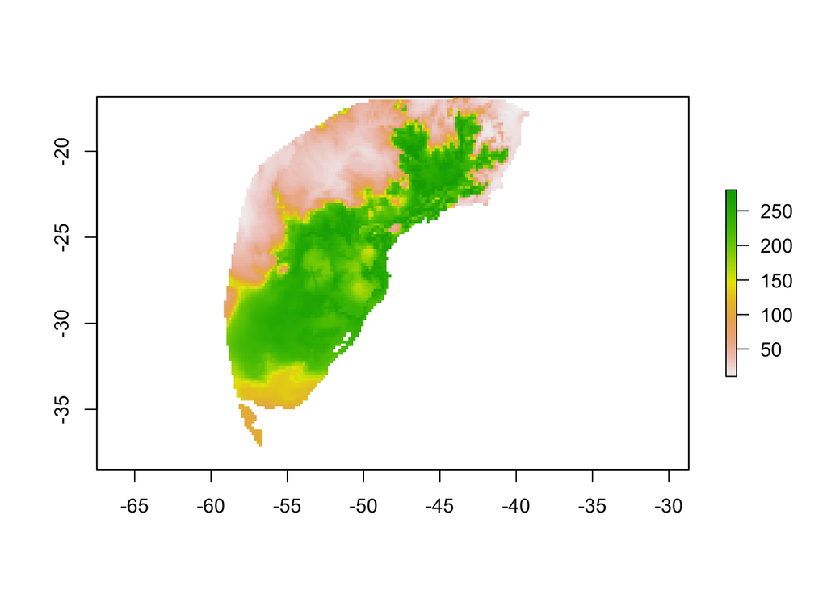

```r
e <- cell_size*e
plot(e) # perceba a mudança na escala
```

```r
resultado <- cellStats(e, sum) # cálculo em km2
resultado
```

```
## [1] 1053295
```

Perceba que a segunda forma é um pouco mais conservadora e tem uma informação biológica importante que sustenta.

## Limitação de dispersão.

Muitos trabalhos com SDMs costumam pensar em cenários de limitação de dispersão. Para obter esse tipo de dado, se projeta os cenários (função `ensemble` do pacote sdm) pensando em um cenário sem limitação de dispersão. Com os resultados dos ensembles, podemos recortar os rasters considerando diferentes cenários de dispersão usando um buffer ao redor das presenças.

```r
# cenário sem limitação de dispersão:
e <- e4
plot(e)
```

[output not shown]

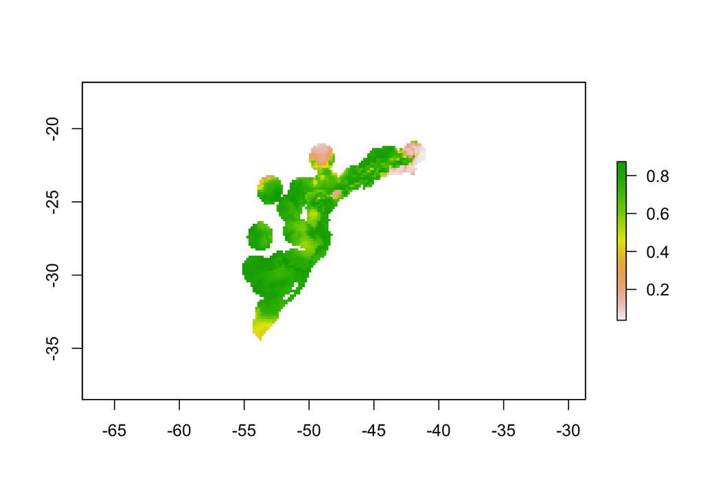

```r
# cenário com limitação de 1 grau (+ou- 110 km no equador):
buf <- gBuffer(df2, width = 1)
e_lim <- mask(e4,buf)
plot(e_lim)
```

Isso também podería ser feito utilizando um polígono da formação florestal da espécie, do bioma ou semelhantes.  
Uma alternativa possível utilizando rasters é binarizar o raster com a variável e multiplicar a variável pelo cenário. Digamos que a minha espécie só ocorre abaixo de 17 graus Celsius de temperatura média. Poderíamos recortar nosso resultado utilizando o raster ambiental de temperatura. Uma aplicação mais real seria utilizando, por exemplo, altitude ou alguma variável categórica de solo, mas vou utilizar a temperatura que já está no nosso ambiente do R. Ficaria assim:

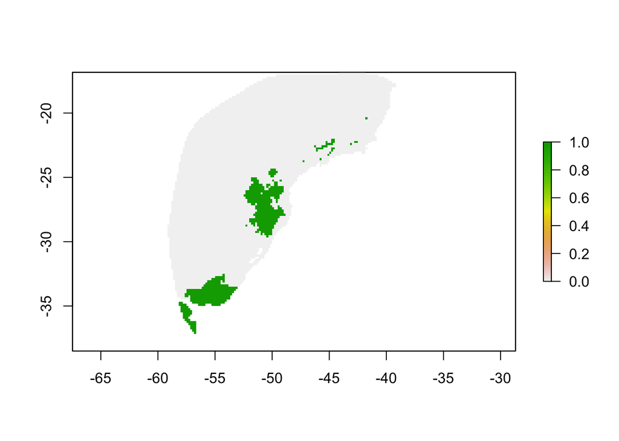

```r
temp <- s[[1]] # selecionando o raster de temperatura
temp[] <- ifelse(temp[] < 17, 1, 0) # binarizando temperatura abaixo de 17 graus
plot(temp)
```

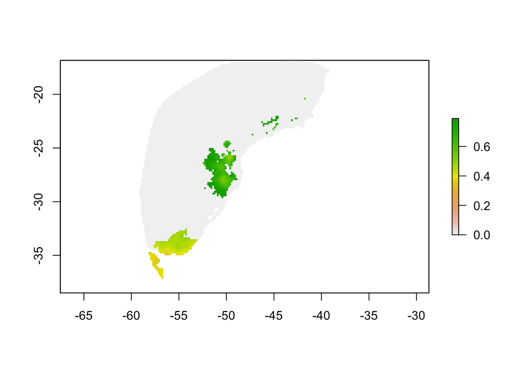

```r
e <- e4*temp # multiplicando valores acima de 17 graus por zero.
plot(e)
```

Com esses resultados podemos recalcular valores de área ou correlação, por exemplo, para observar se há diferenças entre cenários com dispersão limitada ou ilimitada.

## Áreas protegidas e remanescentes

Utilizando a mesma técnica da seção anterior, poderíamos utilizar um polígono de áreas protegidas, terras indígenas, remanescentes florestais ou assemelhados para obter respostas sobre esses polígonos determinados.

## Conclusão

Essas foram algumas das principais ferramentas que utilizamos para processar nossos resultados e chegarmos nas nossas respostas. Perceba que seu uso e parametrização dependem muito mais da pergunta sendo feita do que alguma conveniência ou regra pré-estabelecida.

## Exercício

Hoje não temos exercício, pois a partir de agora o trabalho está nas mãos de vocês.